# Practical Machine Learning

Matthieu Guérin

Sunday, October 26, 2014

# Introduction

This project shows how machine learning technics may be used to try to judge how well human subjects are performing a Weight Lifting Exercise by reading data from various “sensors”.

It uses the Weight Lifting Exercises Dataset from: *Velloso, E.; Bulling, A.; Gellersen, H.; Ugulino, W.; Fuks, H. Qualitative Activity Recognition of Weight Lifting Exercises. Proceedings of 4th International Conference in Cooperation with SIGCHI (Augmented Human ’13) . Stuttgart, Germany: ACM SIGCHI, 2013.*

# Exercice

Six young health participants were asked to perform one set of 10 repetitions of the Unilateral Dumbbell Biceps Curl in five different fashions: exactly according to the specification (Class A), throwing the elbows to the front (Class B), lifting the dumbbell only halfway (Class C), lowering the dumbbell only halfway (Class D) and throwing the hips to the front (Class E).

# Preparing data

The loaded data frame dimensions (rows, columns) are 19622, 160.

The first 8 columns contain descriptive value and a lot of columns have too few variance to be of any use when evaluating our model against the test set (e.g. max_roll_belt).

The next step cleans out those values, we end up with:

The resulting training data dimensions (rows, columns) are 19622, 52.

To be sure, let’s check for near zero variance data,

The number of nzv left is 0.

# Training / testing sets

Let’s split data in two sets:

```r
inTraining <- createDataPartition(data$classe, p = 0.6, list = FALSE)
training <- data[inTraining, ]
testing  <- data[-inTraining, ]
levels(training$classe) <- c("A","B","C","D","E")
levels(testing$classe) <- c("A","B","C","D","E")
```

Lets train our model on the training set with an rpart algorithm.

```r
fit1<-train(classe ~ ., data = training, method = "rpart",
      tuneLength = 50)
```

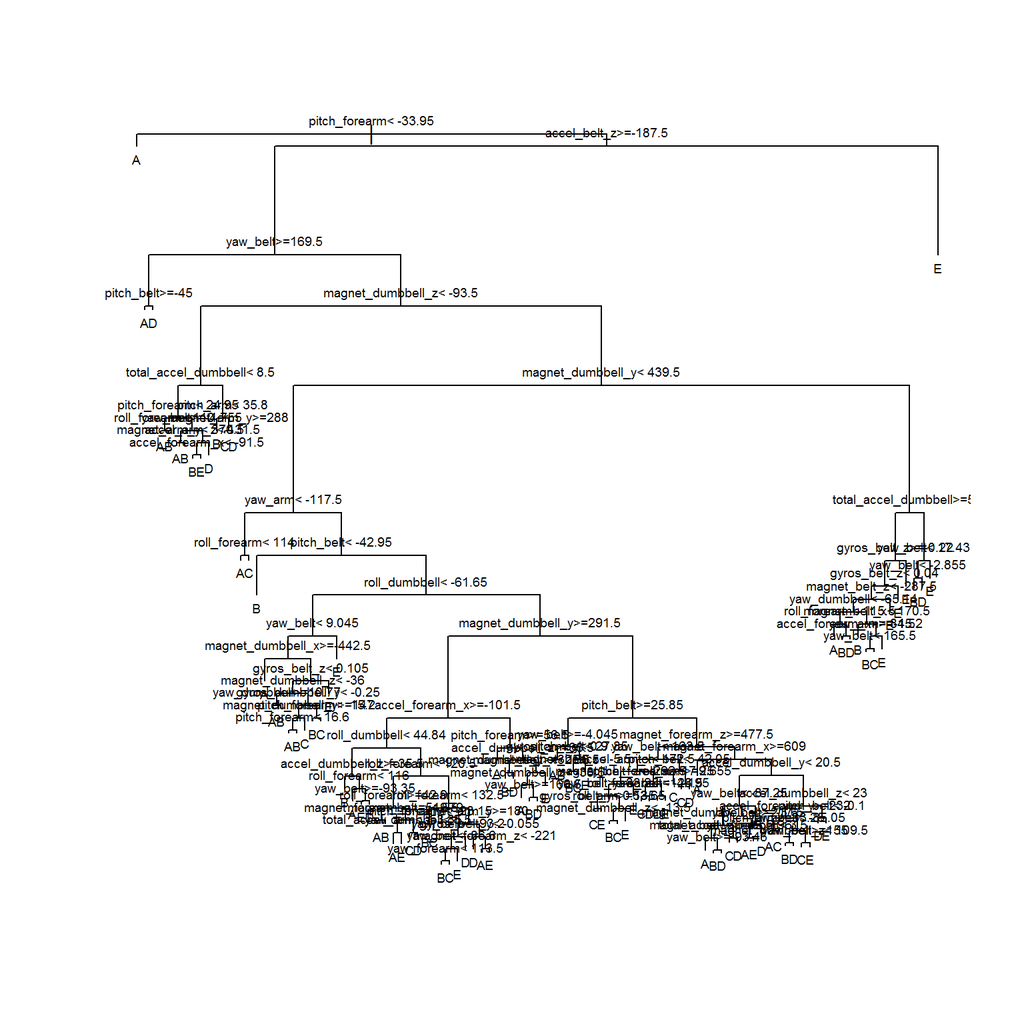

```
## Confusion Matrix and Statistics
##
##           Reference
## Prediction    A    B    C    D    E
##          A 3208  150   33   25   17
##          B   53 1915  115   37   98
##          C   40  115 1806  102   48
##          D   29   38   60 1704   95
##          E   18   61   40   62 1907
##
## Overall Statistics
##
##                Accuracy : 0.895
##                  95% CI : (0.8894, 0.9005)
##     No Information Rate : 0.2843
##     P-Value [Acc > NIR] : < 2.2e-16
##
##                   Kappa : 0.8671
##  Mcnemar's Test P-Value : 5.895e-12
##
## Statistics by Class:
##
##                      Class: A Class: B Class: C Class: D Class: E
## Sensitivity            0.9582   0.8403   0.8793   0.8829   0.8808
## Specificity            0.9733   0.9681   0.9686   0.9775   0.9812
## Pos Pred Value         0.9345   0.8634   0.8555   0.8847   0.9133
## Neg Pred Value         0.9832   0.9619   0.9743   0.9771   0.9734
## Prevalence             0.2843   0.1935   0.1744   0.1639   0.1838
## Detection Rate         0.2724   0.1626   0.1534   0.1447   0.1619
## Detection Prevalence   0.2915   0.1883   0.1793   0.1636   0.1773
## Balanced Accuracy      0.9657   0.9042   0.9239   0.9302   0.9310
```

We see that we have a result of about 0.9 accuracy on the **training** data.

Let’s process the testing data:

```
## Confusion Matrix and Statistics
##
##           Reference
## Prediction    A    B    C    D    E
##          A 2073  122   26   17   11
##          B   67 1223  122   39   91
##          C   34   83 1142   56   32
##          D   39   42   55 1125   58
##          E   19   48   23   49 1250
##
## Overall Statistics
##
##                Accuracy : 0.8683
##                  95% CI : (0.8607, 0.8757)
##     No Information Rate : 0.2845
##     P-Value [Acc > NIR] : < 2.2e-16
##
##                   Kappa : 0.8334
##  Mcnemar's Test P-Value : 1.807e-07
##
## Statistics by Class:
##
##                      Class: A Class: B Class: C Class: D Class: E
## Sensitivity            0.9288   0.8057   0.8348   0.8748   0.8669
## Specificity            0.9686   0.9496   0.9684   0.9704   0.9783
## Pos Pred Value         0.9217   0.7931   0.8478   0.8529   0.8999
## Neg Pred Value         0.9716   0.9532   0.9652   0.9753   0.9703
## Prevalence             0.2845   0.1935   0.1744   0.1639   0.1838
## Detection Rate         0.2642   0.1559   0.1456   0.1434   0.1593
## Detection Prevalence   0.2866   0.1965   0.1717   0.1681   0.1770
## Balanced Accuracy      0.9487   0.8776   0.9016   0.9226   0.9226
```

We see that we have a result of about 0.87 accuracy on the **testing** data.

Looks like our model is not overfitted.